# Tests de cohérence des données

Auteur·rice

Thelma Panaïotis

Date de publication

18 mars 2026

```r
library(tidyverse)
library(here)
library(gt)

# Chargement des données nettoyées
caract_velo <-      readRDS(here("data", "03.caracteristiques_velo_clean.rds"))
usagers_velo <-     readRDS(here("data", "03.usagers_velo_clean.rds"))
vehicules_velo <-   readRDS(here("data", "03.vehicules_velo_clean.rds"))
config_accidents <- readRDS(here("data", "03.config_accidents.rds"))

# Données complètes pour certains tests
caracteristiques <- readRDS(here("data", "03.caracteristiques_clean.rds"))
usagers <-          readRDS(here("data", "03.usagers_clean.rds"))
vehicules <-        readRDS(here("data", "03.vehicules_clean.rds"))
```

## Vue d’ensemble

```r
tibble(
  Indicateur = c(
    "Accidents total Nice",
    "Accidents impliquant un vélo",
    "Vélos (véhicules)",
    "Cyclistes (usagers)",
    "Conducteurs de vélo",
    "Passagers vélo"
  ),
  Nombre = c(
    n_distinct(caracteristiques$Num_Acc),
    n_distinct(caract_velo$Num_Acc),
    vehicules_velo %>% filter(catv %in% c(1, 80)) %>% nrow(),
    usagers_velo %>% nrow(),
    usagers_velo %>% filter(catu == 1) %>% nrow(),
    usagers_velo %>% filter(catu == 2) %>% nrow()
  )
) %>%
  gt() %>%
  tab_header(title = "Statistiques descriptives")
```

Statistiques descriptives

| Indicateur | Nombre |
| --- | --- |
| Accidents total Nice | 14805 |
| Accidents impliquant un vélo | 548 |
| Vélos (véhicules) | 567 |
| Cyclistes (usagers) | 566 |
| Conducteurs de vélo | 561 |
| Passagers vélo | 5 |

**NoteCohérence des chiffres**

**Anomalie :** 6 vélos sans conducteur enregistré dans la base BAAC. Cela peut indiquer :

- Des erreurs de saisie
- Des vélos abandonnés/volés impliqués dans l’accident
- Des données incomplètes

Ces 6 vélos seront identifiés dans le Test 1.3 pour investigation.

# 1. Tests de structure des données

## Test 1.1 : Véhicules vs Usagers cyclistes

Attendu : Nombre de cyclistes supérieur ou égal au nombre de vélos (car passagers possibles)

```r
n_velos <- vehicules_velo %>%
  filter(catv %in% c(1, 80)) %>%
  nrow()

n_cyclistes <- usagers_velo %>%
  filter(catu %in% c(1, 2)) %>%
  nrow()

resultat_1_1 <- ifelse(n_cyclistes >= n_velos, "Ok", "Problème")

tibble(
  Métrique = c("Vélos (véhicules)", "Cyclistes (usagers)", "Différence", "Résultat"),
  Valeur = as.character(c(n_velos, n_cyclistes, n_cyclistes - n_velos, resultat_1_1))
) %>%
  gt()
```

| Métrique | Valeur |
| --- | --- |
| Vélos (véhicules) | 567 |
| Cyclistes (usagers) | 566 |
| Différence | -1 |
| Résultat | Problème |

**AvertissementAnomalie détectée**

- **567 vélos** (véhicules)
- **566 cyclistes** dont **5 passagers**
- Donc **561 conducteurs** pour **567 vélos**

→ **6 vélos sans conducteur**, ce qui est anormal et nécessite une investigation (voir Test 1.3).

## Test 1.2 : Chaque accident a au moins 1 vélo

Attendu : 0 accident sans vélo dans la table caract_velo

```r
accidents_sans_velo <- caract_velo %>%
  anti_join(
    vehicules_velo %>% filter(catv %in% c(1, 80)),
    by = "Num_Acc"
  )

resultat_1_2 <- ifelse(nrow(accidents_sans_velo) == 0, "Ok", "Problème")

tibble(
  Test = "Accidents sans vélo",
  Nombre = nrow(accidents_sans_velo),
  Résultat = resultat_1_2
) %>%
  gt()
```

| Test | Nombre | Résultat |
| --- | --- | --- |
| Accidents sans vélo | 0 | Ok |

## Test 1.3 : Chaque vélo a au moins 1 conducteur

Attendu : 0 vélo sans conducteur

```r
velos_sans_conducteur <- vehicules_velo %>%
  filter(catv %in% c(1, 80)) %>%
  anti_join(
    usagers_velo %>% filter(catu == 1),
    by = c("Num_Acc", "num_veh")
  )

resultat_1_3 <- ifelse(nrow(velos_sans_conducteur) == 0, "Ok", "Problème")

tibble(
  Test = "Vélos sans conducteur",
  Nombre = nrow(velos_sans_conducteur),
  Résultat = resultat_1_3
) %>%
  gt()
```

| Test | Nombre | Résultat |
| --- | --- | --- |
| Vélos sans conducteur | 6 | Problème |

**AvertissementÀ investiguer**

6 vélos sans conducteur ont été identifiés. Ces cas nécessitent une vérification manuelle dans la base BAAC pour déterminer : - S’il s’agit d’erreurs de saisie - Si ce sont des vélos abandonnés/stationnés impliqués dans l’accident - Si les données des conducteurs sont simplement manquantes

**Action recommandée :** Examiner manuellement les 6 accidents concernés.

## Test 1.4 : Pas de doublons

Chaque Num_Acc doit être unique dans la table caract_velo.

```r
doublons <- caract_velo %>%
  count(Num_Acc) %>%
  filter(n > 1)

resultat_1_4 <- ifelse(nrow(doublons) == 0, "Ok", "Problème")

tibble(
  Test = "Accidents en doublon",
  Nombre = nrow(doublons),
  Résultat = resultat_1_4
) %>%
  gt()
```

| Test | Nombre | Résultat |
| --- | --- | --- |
| Accidents en doublon | 0 | Ok |

# 2. Tests de configurations d’accidents

## Test 2.1 : Configuration Vélo seul cohérente

Attendu : Les accidents “Vélo seul” ont exactement 1 véhicule

```r
config_velo_seul_pb <- config_accidents %>%
  filter(configuration == "Vélo seul") %>%
  filter(n_total != 1)

resultat_2_1 <- ifelse(nrow(config_velo_seul_pb) == 0, "Ok", "Problème")

tibble(
  Test = "Vélo seul avec n_total différent de 1",
  Nombre = nrow(config_velo_seul_pb),
  Résultat = resultat_2_1
) %>%
  gt()
```

| Test | Nombre | Résultat |
| --- | --- | --- |
| Vélo seul avec n_total différent de 1 | 0 | Ok |

## Test 2.2 : Piétons dans accidents Vélo vs piéton

Les accidents “Vélo vs piéton” doivent avoir des piétons dans la table usagers.

```r
accidents_velo_pieton <- config_accidents %>%
  filter(configuration == "Vélo vs piéton") %>%
  pull(Num_Acc)

pietons_dans_accidents <- usagers %>%
  filter(Num_Acc %in% accidents_velo_pieton, catu == 3) %>%
  nrow()

resultat_2_2 <- ifelse(pietons_dans_accidents > 0, "Ok", "Problème")

tibble(
  Test = "Piétons dans accidents Vélo vs piéton",
  Nombre = pietons_dans_accidents,
  Résultat = resultat_2_2
) %>%
  gt()
```

| Test | Nombre | Résultat |
| --- | --- | --- |
| Piétons dans accidents Vélo vs piéton | 53 | Ok |

## Test 2.3 : Piétons absents de vehicules

Les piétons ne doivent être que dans usagers, jamais dans vehicules.

```r
accidents_pieton <- config_accidents %>%
  filter(configuration == "Vélo vs piéton") %>%
  pull(Num_Acc)

pietons_vehicules <- vehicules %>%
  filter(Num_Acc %in% accidents_pieton) %>%
  filter(catv == 3 | catv == "pieton")

resultat_2_3 <- ifelse(nrow(pietons_vehicules) == 0, "Ok", "Problème")

tibble(
  Test = "Piétons dans table vehicules",
  Nombre = nrow(pietons_vehicules),
  Résultat = resultat_2_3
) %>%
  gt()
```

| Test | Nombre | Résultat |
| --- | --- | --- |
| Piétons dans table vehicules | 0 | Ok |

## Test 2.4 : Somme des configurations

La somme des configurations doit être égale au nombre total d’accidents vélo.

```r
n_total_accidents <- n_distinct(caract_velo$Num_Acc)
n_total_config <- nrow(config_accidents)

resultat_2_4 <- ifelse(n_total_config == n_total_accidents, "Ok", "Problème")

config_accidents %>%
  count(configuration, sort = TRUE) %>%
  bind_rows(tibble(configuration = "Total", n = sum(.$n))) %>%
  mutate(
    pct = round(n / n_total_config * 100, 1),
    Résultat = ifelse(configuration == "Total", resultat_2_4, "")
  ) %>%
  gt() %>%
  tab_header(title = "Répartition des configurations d'accidents")
```

Répartition des configurations d'accidents

| configuration | n | pct | Résultat |
| --- | --- | --- | --- |
| Vélo vs voiture | 322 | 58.8 |  |
| Vélo vs 2RM | 72 | 13.1 |  |
| Vélo vs piéton | 51 | 9.3 |  |
| Vélo vs poids lourd | 36 | 6.6 |  |
| Autre configuration | 32 | 5.8 |  |
| Vélo seul | 20 | 3.6 |  |
| Vélo vs vélo | 14 | 2.6 |  |
| Vélo vs EDPM | 1 | 0.2 |  |
| Total | 548 | 100.0 | Ok |

## Test 2.5 : n_total cohérent

Le n_total de config_accidents doit correspondre au vrai nombre de véhicules.

```r
verif_n_total <- vehicules_velo %>%
  count(Num_Acc, name = "n_vehicules_reel") %>%
  inner_join(
    config_accidents %>% select(Num_Acc, n_total),
    by = "Num_Acc"
  ) %>%
  filter(n_vehicules_reel != n_total)

resultat_2_5 <- ifelse(nrow(verif_n_total) == 0, "Ok", "Problème")

tibble(
  Test = "Incohérence n_total configurations",
  Nombre = nrow(verif_n_total),
  Résultat = resultat_2_5
) %>%
  gt()
```

| Test | Nombre | Résultat |
| --- | --- | --- |
| Incohérence n_total configurations | 0 | Ok |

# 3. Tests de validité temporelle

## Test 3.1 : Années cohérentes

Les années doivent être comprises entre 2005 et 2024.

```r
annees <- caract_velo %>%
  count(an) %>%
  arrange(an)

annees_pb <- annees %>%
  filter(an < 2005 | an > 2024)

resultat_3_1 <- ifelse(nrow(annees_pb) == 0, "Ok", "Problème")

tibble(
  Test = "Années hors période 2005-2024",
  Nombre = nrow(annees_pb),
  Résultat = resultat_3_1
) %>%
  gt()
```

| Test | Nombre | Résultat |
| --- | --- | --- |
| Années hors période 2005-2024 | 0 | Ok |

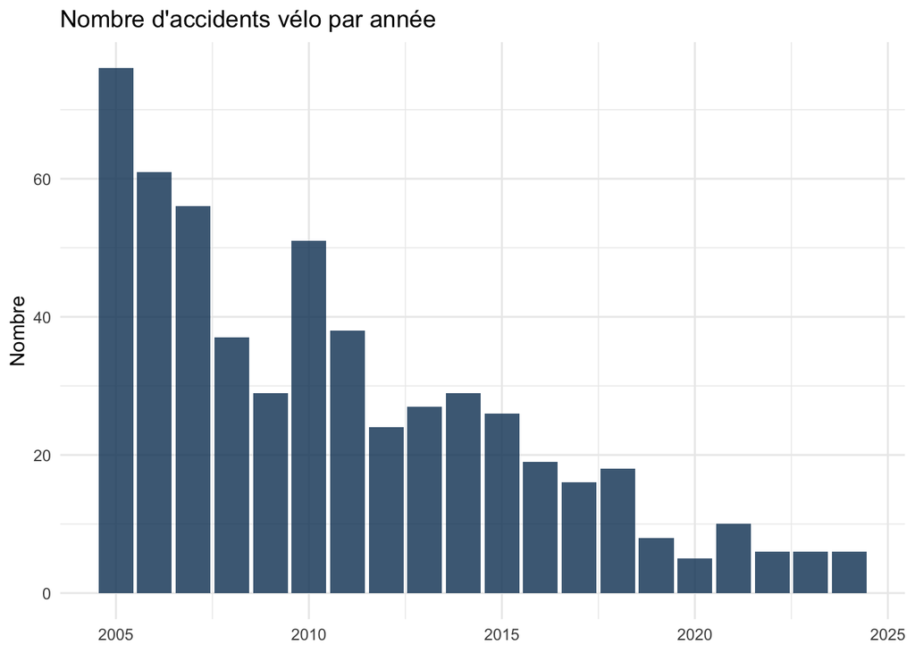

## Test 3.2 : Mois entre 1 et 12

Les mois doivent être compris entre 1 et 12.

```r
mois_invalides <- caract_velo %>%
  mutate(mois_num = as.integer(mois)) %>%
  filter(!is.na(mois_num), (mois_num < 1 | mois_num > 12))

resultat_3_2 <- ifelse(nrow(mois_invalides) == 0, "Ok", "Problème")

tibble(
  Test = "Mois hors plage 1-12",
  Nombre = nrow(mois_invalides),
  Résultat = resultat_3_2
) %>%
  gt()
```

| Test | Nombre | Résultat |
| --- | --- | --- |
| Mois hors plage 1-12 | 0 | Ok |

## Test 3.3 : Format heure HH:MM

Le format hrmn doit être HH:MM.

```r
heures_invalides <- caract_velo %>%
  filter(!is.na(hrmn), hrmn != "", !str_detect(hrmn, "^\\d{2}:\\d{2}$"))

resultat_3_3 <- ifelse(nrow(heures_invalides) == 0, "Ok", "À vérifier")

tibble(
  Test = "Format heure invalide (pas HH:MM)",
  Nombre = nrow(heures_invalides),
  Résultat = resultat_3_3
) %>%
  gt()
```

| Test | Nombre | Résultat |
| --- | --- | --- |
| Format heure invalide (pas HH:MM) | 0 | Ok |

## Test 3.4 : Âges cohérents

Les âges doivent être compris entre 0 et 120 ans.

```r
ages_pb <- usagers_velo %>%
  filter(catu == 1) %>%
  left_join(caract_velo %>% select(Num_Acc, an), by = "Num_Acc") %>%
  mutate(age = an - an_nais) %>%
  filter(!is.na(age)) %>%
  filter(age < 0 | age > 120)

resultat_3_4 <- ifelse(nrow(ages_pb) == 0, "Ok", "À vérifier")

tibble(
  Test = "Âges aberrants (< 0 ou > 120)",
  Nombre = nrow(ages_pb),
  Résultat = resultat_3_4
) %>%
  gt()
```

| Test | Nombre | Résultat |
| --- | --- | --- |
| Âges aberrants (< 0 ou > 120) | 0 | Ok |

# 4. Tests de validité géographique

## Test 4.1 : GPS dans limites de Nice

Les coordonnées GPS doivent être dans les limites de Nice (lat ~43.6-43.75, long ~7.2-7.3).

```r
coords_aberrantes <- caract_velo %>%
  filter(an >= 2019, !is.na(lat), !is.na(long), lat != 0, long != 0) %>%
  filter(lat < 43.6 | lat > 43.75 | long < 7.2 | long > 7.3)

resultat_4_1 <- ifelse(nrow(coords_aberrantes) <= 5, "Ok", "À vérifier")

tibble(
  Test = "Coordonnées GPS hors limites Nice",
  Nombre = nrow(coords_aberrantes),
  Résultat = resultat_4_1
) %>%
  gt()
```

| Test | Nombre | Résultat |
| --- | --- | --- |
| Coordonnées GPS hors limites Nice | 1 | Ok |

**NoteÀ vérifier**

Les coordonnées GPS hors limites de Nice peuvent correspondre à : - Accidents en périphérie (Villefranche, Saint-Laurent-du-Var, etc.) - Erreurs de saisie dans la base BAAC - Problèmes de géocodage

**Action :** Examiner manuellement les accidents concernés pour déterminer s’il s’agit d’erreurs ou d’accidents légitimes en bordure de commune.

## Test 4.2 : GPS uniquement >= 2019

Il ne devrait pas y avoir de GPS avant 2019.

```r
gps_avant_2019 <- caract_velo %>%
  filter(an < 2019, !is.na(lat), !is.na(long), lat != 0, long != 0)

resultat_4_2 <- ifelse(nrow(gps_avant_2019) == 0, "Ok", "À vérifier")

tibble(
  Test = "GPS avant 2019",
  Nombre = nrow(gps_avant_2019),
  Résultat = resultat_4_2
) %>%
  gt()
```

| Test | Nombre | Résultat |
| --- | --- | --- |
| GPS avant 2019 | 0 | Ok |

# 5. Tests de complétude des données

## Test 5.1 : Gravité des cyclistes renseignée

Tous les cyclistes devraient avoir une gravité renseignée.

```r
usagers_velo %>%
  filter(catu %in% c(1, 2)) %>%
  count(grav_label) %>%
  mutate(pct = round(n / sum(n) * 100, 1)) %>%
  gt() %>%
  tab_header(title = "Répartition de la gravité des cyclistes")
```

Répartition de la gravité des cyclistes

| grav_label | n | pct |
| --- | --- | --- |
| Indemne | 76 | 13.4 |
| Blessé léger | 376 | 66.4 |
| Blessé hospitalisé | 100 | 17.7 |
| Tué | 14 | 2.5 |

## Test 5.2 : Taux de renseignement

Les variables importantes doivent être bien renseignées (> 90% attendu).

```r
taux_renseignement <- caract_velo %>%
  summarise(
    Luminosité = round(sum(!is.na(lum) & lum != -1) / n() * 100, 1),
    `Conditions atmosphériques` = round(sum(!is.na(atm) & atm != -1) / n() * 100, 1),
    Collision = round(sum(!is.na(col) & col != -1) / n() * 100, 1),
    Heure = round(sum(!is.na(hrmn) & hrmn != "") / n() * 100, 1),
    Adresse = round(sum(!is.na(adr) & adr != "") / n() * 100, 1)
  ) %>%
  pivot_longer(everything(), names_to = "Variable", values_to = "Taux (%)")

taux_renseignement %>%
  mutate(
    Résultat = ifelse(`Taux (%)` >= 90, "Ok", "À vérifier")
  ) %>%
  gt() %>%
  tab_header(title = "Taux de renseignement des variables clés")
```

Taux de renseignement des variables clés

| Variable | Taux (%) | Résultat |
| --- | --- | --- |
| Luminosité | 100.0 | Ok |
| Conditions atmosphériques | 100.0 | Ok |
| Collision | 99.8 | Ok |
| Heure | 100.0 | Ok |
| Adresse | 100.0 | Ok |

## Test 5.3 : Sexe des conducteurs renseigné

Le sexe des conducteurs doit être majoritairement renseigné.

```r
sexe_manquant <- usagers_velo %>%
  filter(catu == 1, sexe == -1) %>%
  nrow()

total_conducteurs <- usagers_velo %>%
  filter(catu == 1) %>%
  nrow()

pct_manquant <- round(sexe_manquant / total_conducteurs * 100, 1)

resultat_5_3 <- ifelse(pct_manquant < 5, "Ok", "À vérifier")

tibble(
  Test = "Sexe non renseigné pour conducteurs",
  Nombre = sexe_manquant,
  `% du total` = pct_manquant,
  Résultat = resultat_5_3
) %>%
  gt()
```

| Test | Nombre | % du total | Résultat |
| --- | --- | --- | --- |
| Sexe non renseigné pour conducteurs | 1 | 0.2 | Ok |

# 6. Tests métier

## Test 6.1 : Accidents mortels

Vérification de la cohérence des accidents avec tués.

```r
accidents_avec_tue <- usagers_velo %>%
  filter(grav == 2) %>%
  pull(Num_Acc) %>%
  unique()

n_accidents_tues <- length(accidents_avec_tue)
n_tues <- usagers_velo %>% filter(grav == 2) %>% nrow()

tibble(
  Métrique = c("Accidents avec au moins 1 tué", "Nombre total de tués"),
  Valeur = c(n_accidents_tues, n_tues)
) %>%
  gt() %>%
  tab_header(title = "Accidents mortels")
```

Accidents mortels

| Métrique | Valeur |
| --- | --- |
| Accidents avec au moins 1 tué | 14 |
| Nombre total de tués | 14 |

## Test 6.2 : Passagers sur bons véhicules

Les passagers (catu = 2) ne peuvent être que sur certains types de véhicules.

```r
passagers_bizarres <- usagers_velo %>%
  filter(catu == 2) %>%
  inner_join(vehicules_velo, by = c("Num_Acc", "num_veh")) %>%
  filter(!catv %in% c(1, 7, 80))

resultat_6_2 <- ifelse(nrow(passagers_bizarres) <= 2, "Ok", "À vérifier")

tibble(
  Test = "Passagers sur véhicules inhabituels",
  Nombre = nrow(passagers_bizarres),
  Résultat = resultat_6_2
) %>%
  gt()
```

| Test | Nombre | Résultat |
| --- | --- | --- |
| Passagers sur véhicules inhabituels | 0 | Ok |

```r
if (nrow(passagers_bizarres) > 0) {
  passagers_bizarres %>%
    count(catv) %>%
    gt() %>%
    tab_header(title = "Type de véhicules concernés")
}
```

# Résumé global

Résumé des tests de cohérence

| # | Test | Résultat |
| --- | --- | --- |
| 1. Structure |  |  |
| 1.1 | Cyclistes >= Vélos | Problème |
| 1.2 | Pas d'accident sans vélo | Ok |
| 1.3 | Pas de vélo sans conducteur | Problème |
| 1.4 | Pas de doublons | Ok |
| 2. Configurations |  |  |
| 2.1 | Configuration Vélo seul cohérente | Ok |
| 2.2 | Piétons dans accidents piétons | Ok |
| 2.3 | Piétons absents de vehicules | Ok |
| 2.4 | Somme configurations = total | Ok |
| 2.5 | n_total cohérent | Ok |
| 3. Temporel |  |  |
| 3.1 | Années 2005-2024 | Ok |
| 3.2 | Mois 1-12 | Ok |
| 3.3 | Format heure HH:MM | Ok |
| 3.4 | Âges 0-120 | Ok |
| 4. Géographique |  |  |
| 4.1 | GPS dans limites Nice | Ok |
| 4.2 | GPS uniquement >= 2019 | Ok |
| 5. Complétude |  |  |
| 5.1 | Gravité renseignée | Ok |
| 5.2 | Taux renseignement > 90% | Ok |
| 5.3 | Sexe conducteurs renseigné | Ok |
| 6. Métier |  |  |
| 6.1 | Accidents mortels | Ok |
| 6.2 | Passagers sur bons véhicules | Ok |